# Problema 1. Análisis de caso con datos.

Autor/a

Alonso González Romero

Fecha de publicación

17 de octubre de 2025

# Objetivo

El objetivo de este problema es aplicar procesamiento básico de datos reales.

# Importacion de librerias.

**Código**

```python
# Importacion de librerias.
import pandas as pd # Para la manipulacion de dataframes
from itables import init_notebook_mode, show
init_notebook_mode(all_interactive=True)
import matplotlib.pyplot as plt
from matplotlib.patches import Circle, Rectangle, Arc
import seaborn as sns
```

# Lectura y descripción del dataframe.

A continuación, se procede a importar los datos y visualizar las primeras filas del dataframe con el objetivo de entender las variables usadas:

**Código**

```python
datos = pd.read_csv('datos_basket_eventos.csv')
print(datos.head())
```

```
     jugador  minuto tipo_evento          x          y  acierto
0  Jugador_7      22        pase  49.831842  62.528539      NaN
1  Jugador_4      11        pase  27.771585  49.168150      NaN
2  Jugador_8      16        pase  38.449371  33.730066      NaN
3  Jugador_5      33        pase  47.238286  82.456851      NaN
4  Jugador_7       9       falta  42.482370  36.889840      NaN
```

Se observan las siguientes variables:

- **jugador**: Se trata de un identificador del jugador.
- **minuto**: El minuto de juego en el cuál se ha producido el evento.
- **tipo_evento**: El tipo de evento realizado por el jugador, pase, falta, tiro etc…
- **x**: La posición en el eje X respecto a la pista de baloncesto.
- **y**: La posición en el eje Y respecto a la pista de baloncesto.
- **acierto**: Define si el evento realizado ha derivado en un acierto (pase completado, tiro realizado).

# Ejercicios.

## Ejercicio 1. Filtra los tiros realizados en el último cuarto.

Para ello, vamos primeramente a visualizar cuántos minutos tiene el partido, porque desconocemos si es un partido de NBA o ACB y los minutos varían.

**Código**

```python
minim = datos['minuto'].min()
maxim = datos['minuto'].max()
print(f"El minuto más pequeño es: {minim}. Y el más grande es: {maxim}")
```

```
El minuto más pequeño es: 1. Y el más grande es: 40
```

Se observa que el partido dura 40 minutos por lo tanto, ya se tienen todos los datos necesarios para poder filtrar los tiros realizados el ultimo cuarto:

**Código**

```python
tiros_ultimo_cuarto = datos[(datos['minuto']>30) & (datos['tipo_evento']== 'tiro')]
print(tiros_ultimo_cuarto)
```

```
        jugador  minuto tipo_evento          x          y  acierto
18    Jugador_6      33        tiro  26.008175  10.988416      0.0
20    Jugador_5      39        tiro  27.595342  59.004557      1.0
30    Jugador_9      35        tiro   6.818574  23.357979      1.0
41    Jugador_2      35        tiro  31.104335  37.345005      1.0
63   Jugador_10      35        tiro  23.698082  81.979647      1.0
65   Jugador_10      36        tiro   8.615994  53.122519      1.0
76    Jugador_9      33        tiro  25.170864  42.378901      1.0
81    Jugador_9      38        tiro   4.087952  86.559137      1.0
82    Jugador_8      38        tiro  43.678931  81.770258      0.0
86    Jugador_3      34        tiro  40.310064   5.147594      0.0
91    Jugador_1      33        tiro  24.226149  37.427857      0.0
109   Jugador_3      32        tiro  16.103958  62.372513      0.0
119   Jugador_9      32        tiro  26.855327  70.496284      0.0
148   Jugador_4      34        tiro  40.853604  21.721031      0.0
150   Jugador_3      32        tiro   8.544379   1.852791      1.0
158  Jugador_10      37        tiro  16.183962  67.893092      0.0
159   Jugador_8      33        tiro  21.271822  80.435468      0.0
162   Jugador_9      39        tiro   5.741841  62.800003      1.0
167   Jugador_4      35        tiro  24.057005   8.037802      1.0
168   Jugador_7      40        tiro  26.629472  19.541308      1.0
190   Jugador_4      39        tiro   3.324813  84.087909      0.0
```

## Ejercicio 2. Calcula el porcentaje de acierto global y por zona (zona central/laterales izq y derecha)

Para ello, vamos a visualizar primeramente los rangos que tiene la pista, para ello:

**Código**

```python
rangos_X = [datos['x'].min(), datos['x'].max()]
rangos_Y = [datos['y'].min(), datos['y'].max()]

print(f"Los rangos para X: {rangos_X} \n Los rangos para Y: {rangos_Y}")
```

```
Los rangos para X: [np.float64(0.7272332833940964), np.float64(49.83184185369527)]
 Los rangos para Y: [np.float64(0.4354101624326687), np.float64(93.70617967351905)]
```

Vamos a suponer que lo que estamos viendo es una parte de la pista como si estuvieramos jugando sobre ella, es decir, el rango X nos dará el ancho de la pista y el rango Y el largo de la pista. A partir de aquí, y sabiendo que la X tiene un rango de 0-50, vamos a dividir en 3 zonas al campo:

**Código**

```python
division = 50/3
zona_lat_izquierda = [0,division]
zona_central = [division, division*2]
zona_lat_derecha = [division*2, 50]

print(f"Zona lateral izquierda: {zona_lat_izquierda} \n Zona central: {zona_central} \n Zona lateral derecha: {zona_lat_derecha}")
```

```
Zona lateral izquierda: [0, 16.666666666666668]
 Zona central: [16.666666666666668, 33.333333333333336]
 Zona lateral derecha: [33.333333333333336, 50]
```

Bien, una vez extraidas las zonas, vamos a sacar los porcentajes de tiro por zona. Para ello, hacemos lo siguiente:

- Crear una nueva columna que defina la zona.
- Calcular los porcentajes de acierto, primero global y luego por zonas agrupando por la nueva columna realizada.

**Código**

```python
limites = [0, division, division *2, 50]
etiquetas = ['Lateral Izquierda', 'Central', 'Lateral Derecha']
tiros_ultimo_cuarto['zona'] = pd.cut(tiros_ultimo_cuarto['x'], bins = limites, labels = etiquetas, include_lowest=True)

print(tiros_ultimo_cuarto.head())
```

```
       jugador  minuto tipo_evento          x          y  acierto  \
18   Jugador_6      33        tiro  26.008175  10.988416      0.0
20   Jugador_5      39        tiro  27.595342  59.004557      1.0
30   Jugador_9      35        tiro   6.818574  23.357979      1.0
41   Jugador_2      35        tiro  31.104335  37.345005      1.0
63  Jugador_10      35        tiro  23.698082  81.979647      1.0

                 zona
18            Central
20            Central
30  Lateral Izquierda
41            Central
63            Central
```

Tras esto, vamos a visualizar los porcentajes de tiro:

**Código**

```python
porcentaje_tiro_global = (tiros_ultimo_cuarto[(tiros_ultimo_cuarto['acierto'] == 1)].shape[0]/tiros_ultimo_cuarto.shape[0])

porcentaje_tiro_lat_izq = (tiros_ultimo_cuarto[(tiros_ultimo_cuarto['acierto']==1) & (tiros_ultimo_cuarto['zona'] == 'Lateral Izquierda')].shape[0])/(tiros_ultimo_cuarto[(tiros_ultimo_cuarto['zona'] == 'Lateral Izquierda')].shape[0])

porcentaje_tiro_lat_der = (tiros_ultimo_cuarto[(tiros_ultimo_cuarto['acierto']==1) & (tiros_ultimo_cuarto['zona'] == 'Lateral Derecha')].shape[0])/(tiros_ultimo_cuarto[(tiros_ultimo_cuarto['zona'] == 'Lateral Derecha')].shape[0])

porcentaje_tiro_central = (tiros_ultimo_cuarto[(tiros_ultimo_cuarto['acierto']==1) & (tiros_ultimo_cuarto['zona'] == 'Central')].shape[0])/(tiros_ultimo_cuarto[(tiros_ultimo_cuarto['zona'] == 'Central')].shape[0])

print(f"La efectividad global es: {round(porcentaje_tiro_global,2)}. La efectividad en la zona central es: {round(porcentaje_tiro_central,2)}. La efectividad en la zona lateral izquierda es: {round(porcentaje_tiro_lat_izq,2)}. La efectividad en la zona lateral derecha es: {round(porcentaje_tiro_lat_der,2)}")
```

```
La efectividad global es: 0.52. La efectividad en la zona central es: 0.6. La efectividad en la zona lateral izquierda es: 0.62. La efectividad en la zona lateral derecha es: 0.0
```

## Ejercicio 3. Representa en un mapa de tiro (Python)

Para la representación del mapa de tiro, vamos a usar las librerías `matplotlib` y `seaborn`. Primero, crearemos una función que dibuje la media cancha de baloncesto respetando las dimensiones de nuestros datos (eje X de 0 a 50, eje Y de 0 a 90). Después, pintaremos sobre esa cancha los tiros realizados en el último cuarto, distinguiendo entre aciertos y fallos.

**Código**

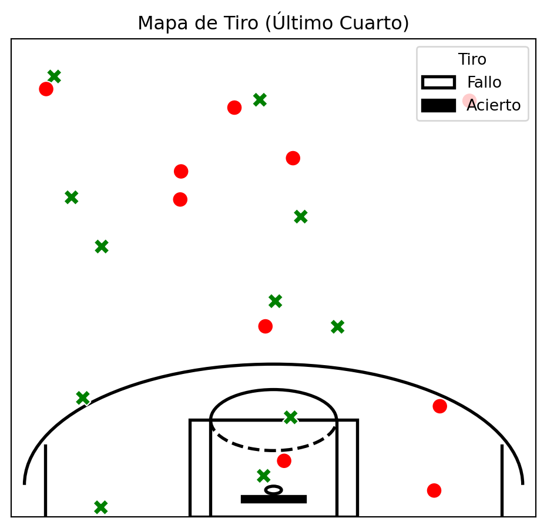

```python
def dibujar_cancha(ax=None, color='black', lw=2):
    """
    Dibuja una media cancha de baloncesto en un eje de matplotlib.
    Las dimensiones se ajustan a los datos del problema (50x90).
    """
    if ax is None:
        ax = plt.gca()

    # Canasta (aro y tablero)
    aro = Circle((25, 5.25), radius=0.75, linewidth=lw, color=color, fill=False)
    tablero = Rectangle((22, 4), 6, -1, linewidth=lw, color=color)

    # Zona (líneas de 3 segundos)
    zona_exterior = Rectangle((17, 0), 16, 19, linewidth=lw, color=color, fill=False)
    zona_interior = Rectangle((19, 0), 12, 19, linewidth=lw, color=color, fill=False)

    # Línea de tres puntos (arco y líneas rectas)
    arco_triple = Arc((25, 6.25), 47.5, 47.5, theta1=0, theta2=180, linewidth=lw, color=color)
    linea_triple_izq = plt.Line2D((3.25, 3.25), (0, 14), linewidth=lw, color=color)
    linea_triple_der = plt.Line2D((46.75, 46.75), (0, 14), linewidth=lw, color=color)

    # Círculo de tiro libre
    circulo_superior = Arc((25, 19), 12, 12, theta1=0, theta2=180, linewidth=lw, color=color)
    circulo_inferior = Arc((25, 19), 12, 12, theta1=180, theta2=360, linewidth=lw, color=color, linestyle='--')

    # Lista de elementos Patch
    elementos_patch = [aro, tablero, zona_exterior, zona_interior, arco_triple,
                       circulo_superior, circulo_inferior]

    # Lista de elementos Line
    elementos_linea = [linea_triple_izq, linea_triple_der]

    # Añadir cada elemento con su método correspondiente
    for elemento in elementos_patch:
        ax.add_patch(elemento)

    for elemento in elementos_linea:
        ax.add_line(elemento)

    return ax

# --- Creación del gráfico ---

# 1. Filtrar solo los tiros (ya lo tienes en tiros_ultimo_cuarto)
tiros_a_pintar = tiros_ultimo_cuarto

# 2. Crear la figura y el eje para el gráfico
plt.figure(figsize=(6, 5.5))
ax = plt.gca()

# 3. Dibujar la cancha en el eje
dibujar_cancha(ax)

# 4. Usar seaborn para pintar los tiros
#    - 'x' e 'y' para las coordenadas
#    - 'hue' para colorear por la columna 'acierto'
#    - 'palette' para elegir los colores (rojo para fallo, verde para acierto)
#    - 'style' para usar diferentes marcadores (círculo para acierto, 'x' para fallo)
#    - 's' para aumentar el tamaño de los puntos
sns.scatterplot(data=tiros_a_pintar, x='x', y='y', hue='acierto', style='acierto',
                palette={0: 'red', 1: 'green'}, s=100, ax=ax)

# 5. Ajustar los límites y la apariencia del gráfico
plt.xlim(0, 50)
plt.ylim(0, 94) # Ajustamos el límite Y para ver toda la media cancha (hasta la línea de fondo)
plt.title('Mapa de Tiro (Último Cuarto)')
ax.set_xlabel('')
ax.set_ylabel('')
ax.tick_params(labelbottom=False, labelleft=False, bottom=False, left=False) # Ocultar ejes y etiquetas
plt.legend(title='Tiro', loc='upper right', labels=['Fallo', 'Acierto'])

# 6. Mostrar el gráfico
plt.show()
```